# Theories of Biostatistics

05 Novemeber, 2025

## Fitting Regression Models

## Introduction to Regression Models

**Purpose:**

- Develop **empirical models** from experimental data
- Predict response at untested factor levels
- Understand relationship between factors and response

**Regression vs. ANOVA:**

- ANOVA: Factors treated as categorical
- Regression: Factors can be quantitative
- Both are special cases of General Linear Model

## Linear Regression Model

**General Form:**

\[y = \beta_0 + \beta_1 x_1 + \beta_2 x_2 + \cdots + \beta_k x_k + \epsilon\]

where:

- \(y\) = response variable
- \(x_i\) = predictor/independent variables
- \(\beta_i\) = regression coefficients (parameters)
- \(\epsilon\) = random error \(\sim N(0, \sigma^2)\)

**Matrix Form:**

\[\mathbf{y} = \mathbf{X}\boldsymbol{\beta} + \boldsymbol{\epsilon}\]

## Model Hierarchy

**First-Order Model:**

\[y = \beta_0 + \beta_1 x_1 + \beta_2 x_2 + \epsilon\]

- Linear in parameters and variables
- No interaction terms
- No curvature

**First-Order with Interaction:**

\[y = \beta_0 + \beta_1 x_1 + \beta_2 x_2 + \beta_{12} x_1 x_2 + \epsilon\]

- Includes two-way interaction
- Still planar (no curvature)

## Model Hierarchy (cont.)

**Second-Order Model:**

\[y = \beta_0 + \sum_{i=1}^k \beta_i x_i + \sum_{i=1}^k \beta_{ii} x_i^2 + \sum\sum_{i<j} \beta_{ij} x_i x_j + \epsilon\]

**Components:**

- **Linear terms:** Main effects
- **Quadratic terms:** Pure curvature
- **Cross-product terms:** Interaction effects

**Parameters:** \(p = \frac{(k+1)(k+2)}{2}\)

For \(k=2\): \(p = 6\) parameters

## Least Squares Estimation

**Objective:** Minimize sum of squared errors

\[SSE = \sum_{i=1}^n (y_i - \hat{y}_i)^2 = \sum_{i=1}^n e_i^2\]

**Normal Equations:**

\[\mathbf{X}'\mathbf{X}\boldsymbol{\beta} = \mathbf{X}'\mathbf{y}\]

**Solution:**

\[\hat{\boldsymbol{\beta}} = (\mathbf{X}'\mathbf{X})^{-1}\mathbf{X}'\mathbf{y}\]

**Properties:** Best Linear Unbiased Estimator (BLUE)

## Fitted Values and Residuals

**Fitted Values:**

\[\hat{\mathbf{y}} = \mathbf{X}\hat{\boldsymbol{\beta}} = \mathbf{X}(\mathbf{X}'\mathbf{X})^{-1}\mathbf{X}'\mathbf{y} = \mathbf{H}\mathbf{y}\]

where \(\mathbf{H}\) is the **hat matrix**

**Residuals:**

\[\mathbf{e} = \mathbf{y} - \hat{\mathbf{y}} = (\mathbf{I} - \mathbf{H})\mathbf{y}\]

**Mean Squared Error:**

\[MS_E = \frac{SSE}{n-p} = \frac{\sum e_i^2}{n-p}\]

where \(p\) = number of parameters

## Hypothesis Testing

**Test for Significance of Regression:**

\[H_0: \beta_1 = \beta_2 = \cdots = \beta_k = 0\]

vs.

\[H_1: \text{At least one } \beta_j \neq 0\]

**F-Test:**

\[F_0 = \frac{SS_R/k}{SSE/(n-p)} = \frac{MS_R}{MS_E}\]

## Hypothesis Testing (cont.)

**Decision Rule:**

Reject \(H_0\) if: \(F_0 > F_{\alpha, k, n-p}\)

**Interpretation:**

- Significant F → Model is useful
- Non-significant F → Model doesn’t explain variation

**P-value:** Probability of observing \(F_0\) or larger if \(H_0\) true

## Regression ANOVA Table

| Source | SS | df | MS | \(F_0\) |
| --- | --- | --- | --- | --- |
| Regression | \(SS_R\) | \(k\) | \(MS_R\) | \(MS_R/MS_E\) |
| Residual | \(SS_E\) | \(n-p\) | \(MS_E\) |  |
| Total | \(SS_T\) | \(n-1\) |  |  |

**Sums of Squares:**

- \(SS_T = \sum (y_i - \bar{y})^2\)
- \(SS_R = \sum (\hat{y}_i - \bar{y})^2\)
- \(SS_E = \sum (y_i - \hat{y}_i)^2\)

**Identity:** \(SS_T = SS_R + SS_E\)

## Coefficient of Determination

**R-Squared:**

\[R^2 = \frac{SS_R}{SS_T} = 1 - \frac{SSE}{SS_T}\]

**Interpretation:**

- Proportion of variation explained by model
- \(0 \leq R^2 \leq 1\)
- Higher is better, but can be misleading

**Adjusted R-Squared:**

\[R^2_{adj} = 1 - \frac{SSE/(n-p)}{SS_T/(n-1)} = 1 - \frac{MS_E}{MS_T}\]

Penalizes for adding unnecessary variables

## Tests on Individual Coefficients

**Hypothesis:**

\[H_0: \beta_j = 0 \quad \text{vs.} \quad H_1: \beta_j \neq 0\]

**t-Test:**

\[t_0 = \frac{\hat{\beta}_j}{SE(\hat{\beta}_j)}\]

where \(SE(\hat{\beta}_j) = \sqrt{MS_E \cdot C_{jj}}\)

and \(C_{jj}\) is the \(j\)th diagonal element of \((\mathbf{X}'\mathbf{X})^{-1}\)

**Reject \(H_0\) if:** \(|t_0| > t_{\alpha/2, n-p}\)

## Confidence Intervals for Coefficients

**For Regression Coefficients:**

\[\hat{\beta}_j \pm t_{\alpha/2, n-p} \cdot SE(\hat{\beta}_j)\]

where:

\[SE(\hat{\beta}_j) = \sqrt{MS_E \cdot C_{jj}}\]

\(C_{jj}\) = \(j\)th diagonal element of \((\mathbf{X}'\mathbf{X})^{-1}\)

**Interpretation:** We are \((1-\alpha)100\)% confident true \(\beta_j\) is in this interval

## Prediction Intervals

**For Mean Response** at \(\mathbf{x}_0\):

\[\hat{y}_0 \pm t_{\alpha/2, n-p} \sqrt{MS_E \cdot \mathbf{x}_0'(\mathbf{X}'\mathbf{X})^{-1}\mathbf{x}_0}\]

**For New Observation:**

\[\hat{y}_0 \pm t_{\alpha/2, n-p} \sqrt{MS_E(1 + \mathbf{x}_0'(\mathbf{X}'\mathbf{X})^{-1}\mathbf{x}_0)}\]

**Note:** Prediction interval is wider (includes \(\sigma^2\) term)

## Model Diagnostics

**Four Key Tools:**

1. **Residual plots** - check assumptions
2. **Normal probability plot** - normality
3. **Influence diagnostics** - influential points
4. **Lack-of-fit test** - model adequacy

**Check for:**

- Non-constant variance
- Non-normality
- Outliers
- Influential observations

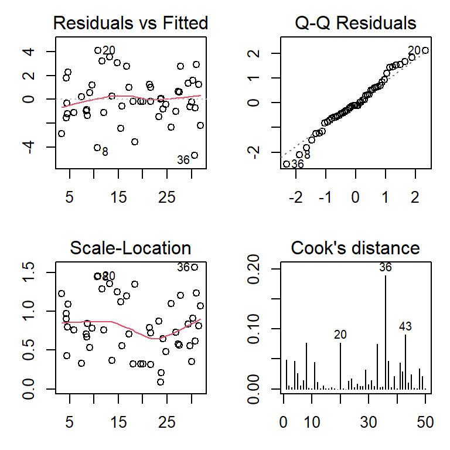

## Standardized Residuals

**Internally Studentized Residuals:**

\[r_i = \frac{e_i}{\sqrt{MS_E(1-h_{ii})}}\]

- \(h_{ii}\) = \(i\)th diagonal element of \(\mathbf{H}\) (hat matrix)
- Used for quick checks of unusual observations

**Externally Studentized Residuals:**

\[t_i = \frac{e_i}{\sqrt{MS_{E(i)}(1-h_{ii})}}\]

- \(MS_{E(i)}\) = MSE computed with \(i\)th observation deleted
- More reliable for outlier detection

**Outlier Detection:** \(|t_i| > t_{\alpha/(2n), n-p-1}\) (Bonferroni)

## Leverage and Influence

**Leverage:**

\[h_{ii} = \mathbf{x}_i'(\mathbf{X}'\mathbf{X})^{-1}\mathbf{x}_i\]

**High leverage if:** \(h_{ii} > \frac{2p}{n}\)

- Measures distance from center of data
- High leverage = unusual factor combination

**Cook’s Distance:**

\[D_i = \frac{r_i^2}{p} \cdot \frac{h_{ii}}{1-h_{ii}}\]

**Influential if:** \(D_i > F_{0.5, p, n-p}\) or \(D_i > 1\)

- Combines leverage and residual size
- Measures impact on fitted values

## PRESS Statistic

**Prediction Error Sum of Squares:**

\[PRESS = \sum_{i=1}^n (y_i - \hat{y}_{(i)})^2 = \sum_{i=1}^n \left(\frac{e_i}{1-h_{ii}}\right)^2\]

- \(\hat{y}_{(i)}\) = predicted value with \(i\)th observation deleted
- Measures prediction accuracy

**PRESS R-Squared:**

\[R^2_{pred} = 1 - \frac{PRESS}{SS_T}\]

**Use:** - Model selection criterion (lower is better) - Should be close to \(R^2_{adj}\) - Large difference indicates overfitting

## Lack of Fit Test

**When replication exists:**

\[SS_E = SS_{LOF} + SS_{PE}\]

**F-Test:**

\[F_0 = \frac{MS_{LOF}}{MS_{PE}} = \frac{SS_{LOF}/(m-p)}{SS_{PE}/(n-m)}\]

where \(m\) = number of distinct design points

**Reject model if:** \(F_0 > F_{\alpha, m-p, n-m}\)

## Response Surface Methodology

## Introduction to RSM

**Response Surface Methodology:**

Optimization technique using designed experiments to:

- Find **optimal** settings
- Model response as function of factors
- Systematically move toward optimum

**Two Phases:**

1. **Screening** - First-order models, identify important factors
2. **Optimization** - Second-order models, find optimum

**Applications:** Process optimization, product design, quality improvement

## Response Surface Concepts

**True Response Function:**

\[y = f(x_1, x_2, \ldots, x_k) + \epsilon\]

**Approximation:**

\[\hat{y} = \hat{f}(x_1, x_2, \ldots, x_k)\]

**Goal:** Find settings that optimize \(\hat{y}\)

**Key Idea:**

- Model response surface
- Find optimal region
- Confirm experimentally

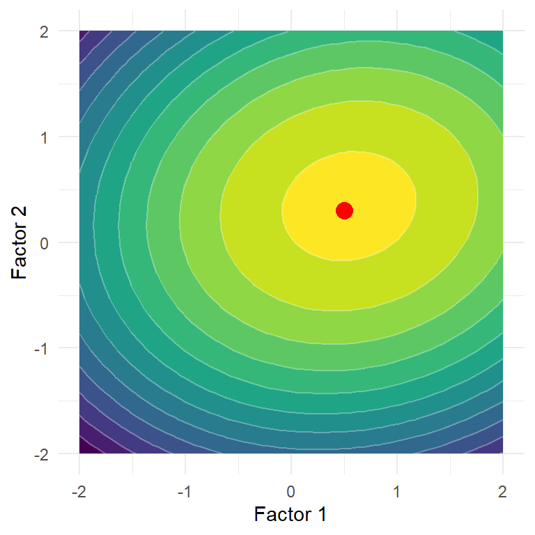

## First-Order Model

**Model:**

\[y = \beta_0 + \beta_1 x_1 + \beta_2 x_2 + \cdots + \beta_k x_k + \epsilon\]

**When to Use:**

- Early stages of experimentation
- Far from optimum
- Screening designs

**Designs:**

- \(2^k\) factorial
- \(2^{k-p}\) fractional factorials

## Method of Steepest Ascent

**Purpose:** Move toward optimum region

**Path:** Direction of maximum increase in response

**Steps along path:**

\[\Delta x_i = \lambda \hat{\beta}_i\]

where \(\lambda\) is step size

**Algorithm:**

1. Fit first-order model
2. Choose step size for one variable
3. Calculate proportional steps for others
4. Run experiments along path
5. Stop when response decreases

## Steepest Ascent Example

**Path Direction:**

Move along gradient of first-order model

**Algorithm:**

1. Fit first-order model
2. Determine path: \(\Delta x_i = \lambda \hat{\beta}_i\)
3. Run experiments along path
4. Stop when response decreases

**Key Point:**

Direction proportional to regression coefficients

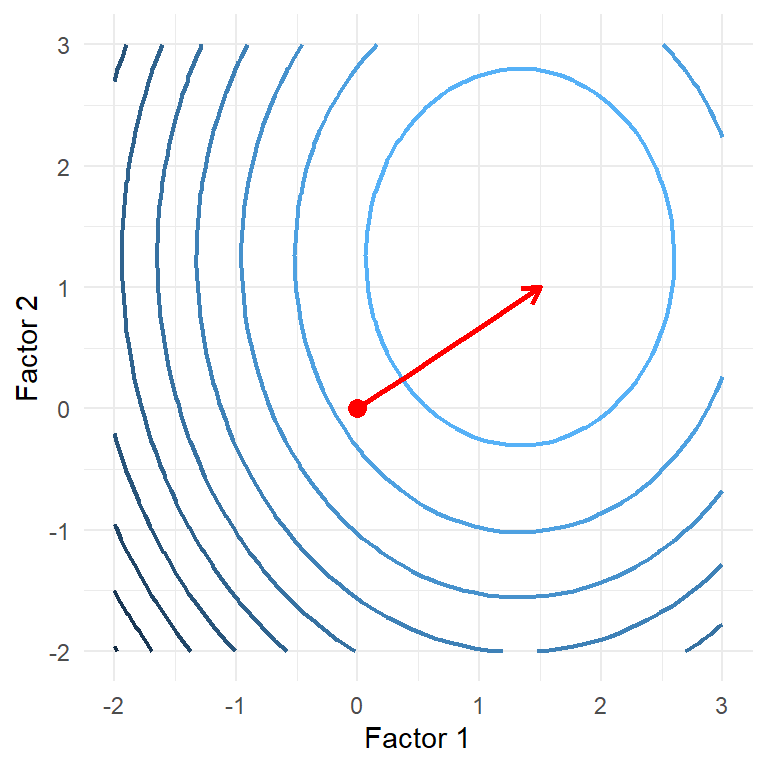

## Second-Order Model

**Full Quadratic Model:**

\[y = \beta_0 + \sum_{i=1}^k \beta_i x_i + \sum_{i=1}^k \beta_{ii} x_i^2 + \sum\sum_{i<j} \beta_{ij} x_i x_j + \epsilon\]

**When to Use:**

- Near optimum
- Significant curvature detected
- Optimization phase

**Parameters:** \(p = \frac{(k+1)(k+2)}{2}\)

For \(k=2\): \(p = 6\) parameters

## Central Composite Design (CCD)

**Structure:**

1. **Factorial points:** \(2^k\) or \(2^{k-p}\) fraction
2. **Axial/star points:** \(2k\) points at distance \(\alpha\) from center
3. **Center points:** \(n_c\) replicates at origin

**Total runs:** \(N = 2^k + 2k + n_c\)

**For \(k=2\):** \(N = 4 + 4 + n_c = 8 + n_c\)

## CCD Geometry

**Design Points:**

1. **Factorial** (blue): \(2^k\) cube corners
2. **Axial** (red): \(2k\) star points
3. **Center** (green): \(n_c\) replicates

**Axial Distance (\(\alpha\)):**

- Rotatable: \(\alpha = (2^k)^{1/4}\)
- Face-centered: \(\alpha = 1\)
- Circumscribed: \(\alpha = \sqrt{k}\)

For \(k=2\): \(\alpha = 1.414\) (rotatable)

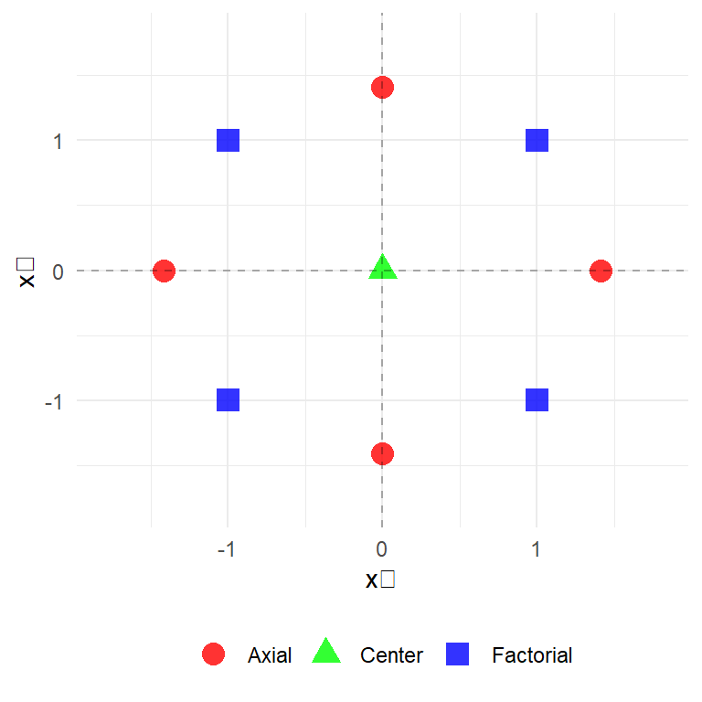

## CCD Types

**Based on \(\alpha\) value:**

1. **Circumscribed (CCC):** \(\alpha = \sqrt{k}\)
   - All points inside hypersphere
2. **Face-Centered (CCF):** \(\alpha = 1\)
   - Axial points on cube faces
   - Good when factor range limited
3. **Inscribed (CCI):** \(\alpha < 1\)
   - All points inside cube

**Rotatability:** \(\alpha = (2^k)^{1/4}\) makes design rotatable

## Box-Behnken Designs

**Alternative to CCD:**

- Three-level design
- No \(2^k\) factorial portion
- Efficient for \(k = 3, 4, 5\) factors

**For \(k=3\):**

- 12 factorial-type runs (edges of cube)
- 3-5 center points
- Total: 15-17 runs

**Advantage:** All points on sphere, no extreme points

## Analysis of Second-Order Model

**Stationary Point:** Where \(\frac{\partial \hat{y}}{\partial x_i} = 0\) for all \(i\)

**Matrix Form:**

\[\hat{y} = \hat{\beta}_0 + \mathbf{x}'\mathbf{b} + \mathbf{x}'\mathbf{B}\mathbf{x}\]

**Stationary Point:**

\[\mathbf{x}_s = -\frac{1}{2}\mathbf{B}^{-1}\mathbf{b}\]

**Response at Stationary Point:**

\[\hat{y}_s = \hat{\beta}_0 + \frac{1}{2}\mathbf{x}_s'\mathbf{b}\]

## Canonical Analysis

**Canonical Form:**

\[\hat{y} = \hat{y}_s + \lambda_1 w_1^2 + \lambda_2 w_2^2 + \cdots + \lambda_k w_k^2\]

where:

- \(\lambda_i\) = eigenvalues of \(\mathbf{B}\)
- \(w_i\) = canonical variables (rotated axes)

**Nature of Stationary Point:**

- All \(\lambda_i > 0\): **Minimum**
- All \(\lambda_i < 0\): **Maximum**
- Mixed signs: **Saddle point**

## Response Surface Types: Maximum

**All \(\lambda_i < 0\)**

**Characteristics:**

- Eigenvalues all negative
- Stationary point is maximum
- Contours are concentric ellipses
- Response decreases in all directions from optimum

**Example:**

\[\hat{y} = 100 - 2x_1^2 - 3x_2^2\]

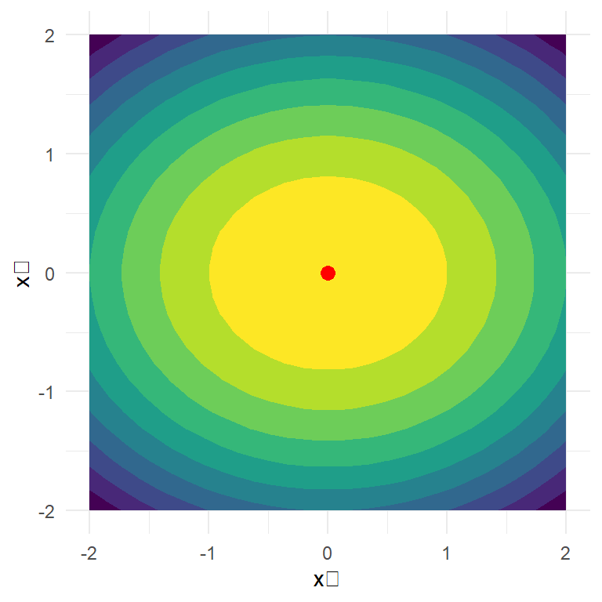

## Response Surface Types: Minimum

**All \(\lambda_i > 0\)**

**Characteristics:**

- Eigenvalues all positive
- Stationary point is minimum
- Contours are concentric ellipses
- Response increases in all directions from optimum

**Example:**

\[\hat{y} = 20 + 2x_1^2 + 3x_2^2\]

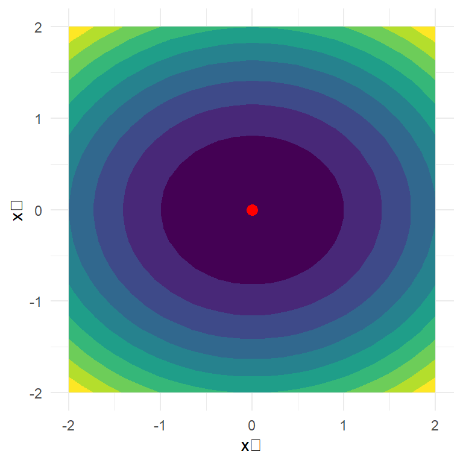

## Response Surface Types: Saddle Point

**Mixed Signs of \(\lambda_i\)**

**Characteristics:**

- Some eigenvalues positive, some negative
- Stationary point is saddle
- Hyperbolic contours
- Maximum in one direction, minimum in another

**Example:**

\[\hat{y} = 50 + 3x_1^2 - 2x_2^2\]

**Action:** Use ridge analysis

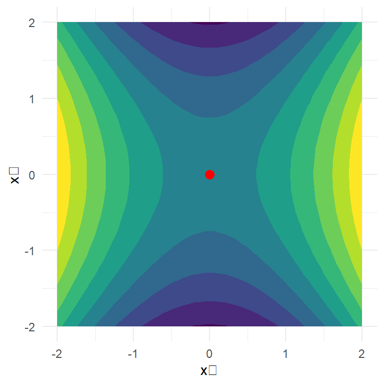

## Ridge Analysis

**When stationary point is outside region:**

Use **ridge analysis** to find:

- Direction of steepest ascent/descent
- Maximum/minimum on spherical regions
- Constrained optimization

**Ridge System:**

\[\max/\min \quad \hat{y} = \hat{\beta}_0 + \mathbf{x}'\mathbf{b} + \mathbf{x}'\mathbf{B}\mathbf{x}\]

subject to: \(\mathbf{x}'\mathbf{x} = R^2\)

## Robust Parameter Design

## Introduction to Robust Design

**Goal:** Make products/processes **insensitive** to:

- Environmental variation (noise factors)
- Component variation
- Deterioration over time

**Taguchi’s Approach:**

- Parameter design
- Robust design
- Quality loss function

**Key Concept:** Design for **robustness**, not just performance

## Noise Factors

**Three Types:**

**1. External (Environmental):**

- Temperature, humidity, altitude
- User-to-user variation

**2. Internal (Unit-to-Unit):**

- Manufacturing variation
- Material property variation

**3. Deterioration:**

- Wear over time
- Aging effects
- Degradation

**Goal:** Design to be robust to all three types

## Signal-to-Noise Ratios

**Taguchi’s S/N Ratios:**

**Smaller-the-Better:** \[\eta = -10\log_{10}\left(\frac{1}{n}\sum y_i^2\right)\]

**Larger-the-Better:** \[\eta = -10\log_{10}\left(\frac{1}{n}\sum \frac{1}{y_i^2}\right)\]

**Nominal-the-Best:** \[\eta = 10\log_{10}\left(\frac{\bar{y}^2}{s^2}\right)\]

Higher S/N is better

## Crossed Array Designs

**Structure:**

- **Inner array:** Control factors (we can set)
- **Outer array:** Noise factors (vary in field)

**Crossed design:** Run each inner array combination at all outer array settings

**Analysis:**

- Find control factor settings that minimize variation from noise
- Adjust mean to target

## Crossed Array Example

Crossed Array Design Structure

| Run | A | B | N1=-1,N2=-1 | N1=1,N2=-1 | N1=-1,N2=1 | N1=1,N2=1 |
| --- | --- | --- | --- | --- | --- | --- |
| 1 | -1 | -1 | y11 | y12 | y13 | y14 |
| 2 | 1 | -1 | y21 | y22 | y23 | y24 |
| 3 | -1 | 1 | y31 | y32 | y33 | y34 |
| 4 | 1 | 1 | y41 | y42 | y43 | y44 |

## Problems with Crossed Arrays

**Disadvantages:**

1. **Inefficient** - requires many runs
2. **Confounding** - location and dispersion effects mixed
3. **Analysis** - S/N ratios problematic

**Better Approach:**

- **Combined array** designs
- **Response model** approach
- Model both mean and variance

## Combined Array Approach

**Single Design:**

- Include both control and noise factors
- Fewer runs than crossed array
- Model response directly

**Analysis:**

\[y = f(\text{control factors}, \text{noise factors})\]

**Goal:** Find control factor settings where:

- Mean is on target
- Response insensitive to noise

## Response Model Method

**Dual Response Approach:**

1. **Model the mean:** \(\hat{\mu} = f(\text{control factors})\)
2. **Model the variance:** \(\hat{\sigma}^2 = g(\text{control factors})\)

**Optimization:**

- Minimize variance
- Adjust mean to target using adjustment factor

**Example:**

\[\min \quad \hat{\sigma}^2\]

subject to: \(\hat{\mu} = \text{target}\)

## Robust Design Strategy

**Sequential Process:**

1. **Screening:** Identify important control and noise factors
2. **Modeling:** Build response models for mean and variance
3. **Optimization:** Find robust operating conditions
4. **Confirmation:** Verify results

**Key:** Use **statistical design** principles throughout

## Random Effects Models

## Fixed vs. Random Effects

**Fixed Effects:**

- Factor levels specifically chosen
- Inference only for tested levels
- Example: 3 specific temperatures

**Random Effects:**

- Factor levels randomly selected from population
- Inference for entire population
- Example: Random sample of operators

**Model Difference:**

- Fixed: \(\tau_i\) are constants, \(\sum \tau_i = 0\)
- Random: \(\tau_i \sim N(0, \sigma_\tau^2)\)

## One-Way Random Effects Model

**Model:**

\[y_{ij} = \mu + \tau_i + \epsilon_{ij}\]

where:

- \(\tau_i \sim N(0, \sigma_\tau^2)\) - random treatment effects
- \(\epsilon_{ij} \sim N(0, \sigma^2)\) - random errors
- \(\tau_i\) and \(\epsilon_{ij}\) are independent

**Variance Components:**

- \(\sigma_\tau^2\) = between-treatment variance
- \(\sigma^2\) = within-treatment (error) variance

## Expected Mean Squares

**ANOVA Table for Random Effects:**

| Source | E(MS) |
| --- | --- |
| Treatments | \(\sigma^2 + n\sigma_\tau^2\) |
| Error | \(\sigma^2\) |

**Note:** Different from fixed effects!

**F-Test still valid:**

\[F_0 = \frac{MS_{Treatments}}{MS_E} \sim F_{a-1, a(n-1)}\]

## Variance Component Estimation

**Method of Moments (ANOVA Method):**

\[\hat{\sigma}^2 = MS_E\]

\[\hat{\sigma}_\tau^2 = \frac{MS_{Treatments} - MS_E}{n}\]

**Important:** If \(\hat{\sigma}_\tau^2 < 0\), set \(\hat{\sigma}_\tau^2 = 0\)

**REML (Restricted Maximum Likelihood):**

- Preferred modern method
- Always gives non-negative estimates
- Better for unbalanced data
- Available in `lme4`, `nlme` packages

## Two-Factor Random Model

**Model:**

\[y_{ijk} = \mu + \alpha_i + \beta_j + (\alpha\beta)_{ij} + \epsilon_{ijk}\]

where all effects are random:

- \(\alpha_i \sim N(0, \sigma_\alpha^2)\)
- \(\beta_j \sim N(0, \sigma_\beta^2)\)
- \((\alpha\beta)_{ij} \sim N(0, \sigma_{\alpha\beta}^2)\)
- \(\epsilon_{ijk} \sim N(0, \sigma^2)\)

## Expected Mean Squares: Two-Factor Random

| Source | E(MS) |
| --- | --- |
| A | \(\sigma^2 + n\sigma_{\alpha\beta}^2 + bn\sigma_\alpha^2\) |
| B | \(\sigma^2 + n\sigma_{\alpha\beta}^2 + an\sigma_\beta^2\) |
| AB | \(\sigma^2 + n\sigma_{\alpha\beta}^2\) |
| Error | \(\sigma^2\) |

**Test Statistics:**

\[F_A = \frac{MS_A}{MS_{AB}}, \quad F_B = \frac{MS_B}{MS_{AB}}, \quad F_{AB} = \frac{MS_{AB}}{MS_E}\]

**Note:** Different denominators than fixed effects!

## Mixed Models

**One factor fixed, one random:**

\[y_{ijk} = \mu + \tau_i + \beta_j + (\tau\beta)_{ij} + \epsilon_{ijk}\]

- \(\tau_i\) fixed, \(\sum \tau_i = 0\)
- \(\beta_j \sim N(0, \sigma_\beta^2)\)
- \((\tau\beta)_{ij} \sim N(0, \sigma_{\tau\beta}^2)\)

**Expected Mean Squares differ from both fixed and random!**

## Rules for Expected Mean Squares

**General Algorithm:**

1. Write model equation
2. Identify random terms
3. Apply EMS rules based on:
   - Factor is fixed or random
   - Subscripts in model terms
   - Replication structure

**Software:** Most packages compute EMS automatically

## Nested and Split-Plot Designs

## Nested Designs

**Structure:**

- Levels of one factor **nested** within levels of another
- Not all combinations occur

**Example:**

- Factor A: Suppliers (3 levels)
- Factor B: Batches (4 per supplier)
- Batches from supplier 1 are different from batches from supplier 2

**Notation:** \(B(A)\) means B nested in A

## Two-Stage Nested Design

**Model:**

\[y_{ijk} = \mu + \tau_i + \beta_{j(i)} + \epsilon_{ijk}\]

where:

- \(i = 1, \ldots, a\) (levels of factor A)
- \(j = 1, \ldots, b\) (levels of B nested within each A)
- \(k = 1, \ldots, n\) (replicates)
- \(\beta_{j(i)}\) means \(j\)th level of B within \(i\)th level of A

**Not a Factorial!**

Total runs: \(N = abn\)

Can’t test A×B interaction (doesn’t exist in nested design)

## Nested ANOVA

**ANOVA Table:**

| Source | df | SS Formula |
| --- | --- | --- |
| A | \(a-1\) | \(bn\sum(\bar{y}_{i..} - \bar{y}_{...})^2\) |
| B(A) | \(a(b-1)\) | \(n\sum\sum(\bar{y}_{ij.} - \bar{y}_{i..})^2\) |
| Error | \(ab(n-1)\) | \(\sum\sum\sum(y_{ijk} - \bar{y}_{ij.})^2\) |
| Total | \(abn-1\) |  |

**Cannot test A×B interaction** (doesn’t exist!)

## Staggered Nested Designs

**Unequal nesting:**

- Different number of nested levels
- Example: Different number of batches per supplier

**Advantage:** More realistic

**Analysis:**

- Unbalanced
- Use REML or ML estimation

## Three-Stage Nested Design

**Model:**

\[y_{ijkl} = \mu + \alpha_i + \beta_{j(i)} + \gamma_{k(ij)} + \epsilon_{ijkl}\]

where:

- \(\alpha_i\) = effect of factor A (e.g., lots)
- \(\beta_{j(i)}\) = effect of B nested in A (e.g., wafers in lots)
- \(\gamma_{k(ij)}\) = effect of C nested in AB (e.g., sites on wafers)
- \(\epsilon_{ijkl}\) = error term

**Variance Components:**

\[\sigma_\alpha^2, \quad \sigma_\beta^2, \quad \sigma_\gamma^2, \quad \sigma^2\]

Each represents variation at different hierarchy levels

## Split-Plot Designs

**Origin:** Agricultural experiments

**Structure:**

- **Whole-plot** factor: Hard to change
- **Subplot** factor: Easy to change
- Restriction on randomization

**Example:**

- Whole-plot: Temperature (oven)
- Subplot: Time (multiple specimens per oven setting)

## Split-Plot Model

**Model:**

\[y_{ijk} = \mu + \tau_i + \delta_{j(i)} + \beta_k + (\tau\beta)_{ik} + \epsilon_{ijk}\]

where:

- \(\tau_i\) = whole-plot treatment effect (fixed)
- \(\delta_{j(i)}\) = whole-plot error (random), \(\delta_{j(i)} \sim N(0, \sigma_\delta^2)\)
- \(\beta_k\) = subplot treatment effect (fixed)
- \((\tau\beta)_{ik}\) = interaction effect
- \(\epsilon_{ijk}\) = subplot error (random), \(\epsilon_{ijk} \sim N(0, \sigma^2)\)

**Key Feature:** Two error terms with different properties

## Split-Plot ANOVA Table

| Source | df | F-test |
| --- | --- | --- |
| Whole-plot (A) | \(a-1\) | \(MS_A/MS_\delta\) |
| WP Error (\(\delta\)) | \(a(n-1)\) | — |
| Subplot (B) | \(b-1\) | \(MS_B/MS_\epsilon\) |
| A×B | \((a-1)(b-1)\) | \(MS_{AB}/MS_\epsilon\) |
| SP Error (\(\epsilon\)) | \(a(n-1)(b-1)\) | — |

**Critical Point:** Two different error terms!

- Test A using whole-plot error
- Test B and A×B using subplot error

## Why Use Split-Plots?

**Reasons:**

1. **Hard-to-change factors**
   - Temperature, pressure, machinery setup
2. **Cost/time efficiency**
   - Expensive to reset factor levels
3. **Practical constraints**
   - Physical limitations

**Trade-off:** Less precision for whole-plot factor

## Split-Plot vs. Completely Randomized

CRD vs. Split-Plot Comparison

| Aspect | Completely Randomized | Split-Plot |
| --- | --- | --- |
| Randomization | Full randomization | Restricted randomization |
| Error terms | One error term | Two error terms |
| Precision | Equal for all factors | Lower for whole-plot |
| When to use | All factors easy to change | Some factors hard to change |

## Strip-Plot Design

**Structure:**

- Two factors in strips (rows and columns)
- Both factors hard to change
- Interaction easier to estimate than main effects

**Example:**

- Row factor: Irrigation method
- Column factor: Fertilizer type
- Plots at intersections

**Three error terms!**

## Other Topics

## Nonnormality of Response

**When normality assumption violated:**

1. **Transformations**
   - Log, square root, reciprocal
2. **Nonparametric methods**
   - Rank-based tests
   - Distribution-free
3. **Generalized Linear Models (GLM)**
   - Link functions
   - Alternative distributions

## Box-Cox Transformation

**Power Transformation:**

\[y^{(\lambda)} = \begin{cases} \frac{y^\lambda - 1}{\lambda} & \lambda \neq 0 \\ \log(y) & \lambda = 0 \end{cases}\]

**Estimate \(\lambda\):**

Maximize log-likelihood or minimize SSE

**Common values:**

- \(\lambda = 1\): No transformation
- \(\lambda = 0.5\): Square root
- \(\lambda = 0\): Log
- \(\lambda = -1\): Reciprocal

## Box-Cox Example

**Power Transformation:**

\[y^{(\lambda)} = \begin{cases} \frac{y^\lambda - 1}{\lambda} & \lambda \neq 0 \\ \log(y) & \lambda = 0 \end{cases}\]

**Selection Method:**

- Maximize log-likelihood
- Or minimize SSE

**Common Values:**

- \(\lambda = 1\): No transform
- \(\lambda = 0.5\): Square root
- \(\lambda = 0\): Log
- \(\lambda = -1\): Reciprocal

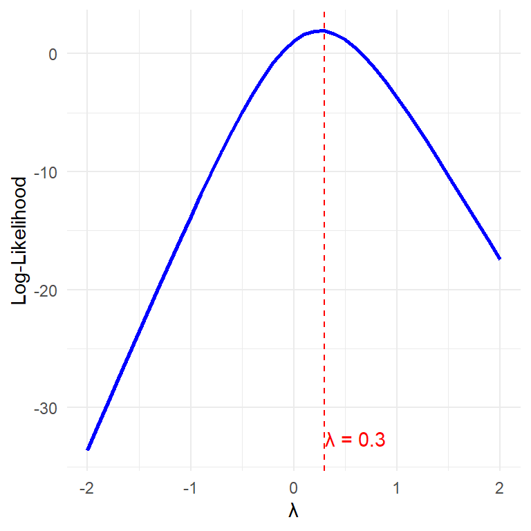

## Unbalanced Data

**Causes:**

- Missing observations
- Unequal replication by design
- Data loss during experiment

**Problems:**

- Non-orthogonal designs
- Type I vs. Type III SS
- Interpretation complexity

**Solutions:**

- Use Type III SS (for unbalanced factorial)
- REML for random/mixed models
- Careful interpretation

## Analysis of Covariance (ANCOVA)

**Purpose:**

- Adjust for **concomitant variable** (covariate)
- Increase precision
- Remove bias

**Model:**

\[y_{ij} = \mu + \tau_i + \beta(x_{ij} - \bar{x}) + \epsilon_{ij}\]

where:

- \(x_{ij}\) = covariate
- \(\beta\) = regression coefficient
- \(\tau_i\) = adjusted treatment effects

## ANCOVA in Factorial Designs

**Include covariate in factorial:**

\[y = \mu + \tau_i + \beta_j + (\tau\beta)_{ij} + \beta x + \epsilon\]

**Benefits:**

- Reduced error variance
- Adjusted treatment effects
- Control for confounder

**Assumptions:**

- Linear relationship with covariate
- Homogeneous slopes (equal \(\beta\) across treatments)
- Covariate measured without error

## Repeated Measures

**Structure:**

- Same experimental unit measured multiple times
- Temporal correlation
- Within-subject design

**Example:**

- Subjects measured at multiple time points
- Patients receiving multiple treatments

**Analysis:**

- Account for correlation structure
- Mixed models
- Multivariate approach

## Repeated Measures ANOVA

**Model:**

\[y_{ijk} = \mu + \alpha_i + \delta_k + (\alpha\delta)_{ik} + \epsilon_{ijk}\]

where:

- \(\alpha_i\) = subject effect (random), \(\alpha_i \sim N(0, \sigma_\alpha^2)\)
- \(\delta_k\) = time/condition effect (within-subject factor)
- \((\alpha\delta)_{ik}\) = subject × time interaction

**Sphericity Assumption:**

\[Var(y_{ijk} - y_{ijk'}) = \text{constant}\] for all pairs \(k, k'\)

If violated: Use **Greenhouse-Geisser** or **Huynh-Feldt** correction

## Design for Computer Experiments

**Computer simulations:**

- Deterministic (no random error)
- Can be expensive to run
- Different design objectives

**Space-Filling Designs:**

- Latin hypercube sampling
- Uniform design
- Maximin distance

**Kriging/Gaussian Process Models:**

- Interpolation
- Prediction with uncertainty

## Summary: Unit 5: Advanced Statistical Data Analysis

## Key Concepts Review

**Chapter 10: Regression** - Least squares: \(\hat{\boldsymbol{\beta}} = (\mathbf{X}'\mathbf{X})^{-1}\mathbf{X}'\mathbf{y}\) - Diagnostics: residuals, leverage, Cook’s D, PRESS

**RSM** - Steepest ascent for screening - CCD for optimization - Canonical analysis: \(\hat{y} = \hat{y}_s + \sum \lambda_i w_i^2\)

## Key Concepts Review (cont.)

**Chapter 12: Robust Design** - S/N ratios for robustness - Combined arrays more efficient

**Random Effects** - Variance components: \(\sigma_\tau^2, \sigma^2\) - Expected mean squares determine F-tests

**Nested & Split-Plot** - Multiple error terms - Restrictions on randomization

**Advanced** - Box-Cox transformations - ANCOVA, repeated measures

## Experimental Design Strategy

**Complete Process:**

1. **Define objectives** clearly
2. **Select appropriate design**
   - Screening: Fractional factorials
   - Optimization: RSM designs
   - Robustness: Combined arrays
3. **Fit appropriate model**
4. **Check assumptions** (diagnostics)
5. **Interpret and optimize**
6. **Confirm results**

## Software Tools

**Recommended Packages:**

- **R packages:** rsm, lme4, nlme, FrF2
- **Commercial:** Design-Expert, JMP, Minitab
- **Python:** pyDOE, scipy.optimize

**Key Features:**

- Design generation
- Model fitting
- Diagnostic plots
- Optimization tools

## Best Practices

**Design Phase:**

✓ Use blocking when appropriate

✓ Include center points

✓ Plan for model hierarchy

✓ Consider follow-up experiments

**Analysis Phase:**

✓ Check residual plots

✓ Test for lack of fit

✓ Use appropriate error terms

✓ Report confidence intervals

## Common Pitfalls to Avoid

❌ Ignoring restrictions on randomization

❌ Using wrong error term (split-plots)

❌ Over-fitting models

❌ Ignoring practical constraints

❌ Not confirming results

## Advanced Topics

**Beyond this course:**

- Optimal design theory
- Bayesian design
- Computer experiments
- Definitive screening designs
- Split-plot response surfaces
- Mixture designs

## Final Thoughts

**Design of Experiments is:**

- Essential for efficient research
- Applicable across disciplines
- Both science and art
- Requires iteration and learning

**Key to Success:**

- Understand your process
- Choose appropriate designs
- Use statistical thinking
- Validate conclusions

**Practice makes perfect!**

## Appendix: R Code Examples

## RSM Example with CCD

```r
# Note: Requires 'rsm' package
# Install with: install.packages("rsm")

if (require("rsm", quietly = TRUE)) {
  library(rsm)

  # Create Central Composite Design
  ccd_design <- ccd(
    basis = 2,  # 2 factors
    n0 = 5,     # 5 center points
    alpha = "rotatable",
    coding = list(
      x1 ~ (Time - 85)/5,
      x2 ~ (Temp - 175)/5
    )
  )

  # Fit second-order model
  rsm_model <- rsm(yield ~ SO(x1, x2), data = ccd_design)

  # Canonical analysis
  summary(rsm_model)

  # Contour plot
  contour(rsm_model, ~ x1 + x2, image = TRUE)

  # Find stationary point
  canonical(rsm_model)
} else {
  message("Install 'rsm' package: install.packages('rsm')")
}
```

## Mixed Model Example

```r
# Note: Requires 'lme4' package
# Install with: install.packages("lme4")

if (require("lme4", quietly = TRUE)) {
  library(lme4)

  # Fit mixed model with random effects
  mixed_model <- lmer(
    response ~ treatment + (1|batch) + (1|operator),
    data = mydata
  )

  # Summary
  summary(mixed_model)

  # Variance components
  VarCorr(mixed_model)

  # Random effects
  ranef(mixed_model)
} else {
  message("Install 'lme4' package: install.packages('lme4')")
}
```

## Split-Plot Analysis

```r
# Note: Requires 'lme4' package
# Install with: install.packages("lme4")

if (require("lme4", quietly = TRUE)) {
  library(lme4)

  # Split-plot model
  # whole_plot is hard-to-change factor
  # sub_plot is easy-to-change factor

  sp_model <- lmer(
    response ~ whole_plot * sub_plot + (1|replicate/whole_plot),
    data = split_plot_data
  )

  # ANOVA-like table
  anova(sp_model)

  # Emmeans for comparisons (if emmeans package available)
  if (require("emmeans", quietly = TRUE)) {
    library(emmeans)
    emmeans(sp_model, pairwise ~ whole_plot | sub_plot)
  }
} else {
  message("Install 'lme4' package: install.packages('lme4')")
}
```

## References and Resources

## Primary Textbook

Montgomery, D. C. (2012). *Design and Analysis of Experiments* (8th ed.). John Wiley & Sons.

**Covered:Unit 5: Advanced Statistical Data Analysis**

## Additional References

**Response Surface Methodology:**

- Myers, R. H., Montgomery, D. C., & Anderson-Cook, C. M. (2016). *Response Surface Methodology* (4th ed.).

**Mixed Models:**

- Pinheiro, J. C., & Bates, D. M. (2000). *Mixed-Effects Models in S and S-PLUS*.

**Robust Design:**

- Wu, C. F. J., & Hamada, M. S. (2009). *Experiments: Planning, Analysis, and Optimization* (2nd ed.).

## R Packages

- **rsm:** Response surface methods
- **lme4:** Linear mixed-effects models
- **nlme:** Nonlinear mixed-effects models
- **FrF2:** Fractional factorial designs
- **AlgDesign:** Algorithmic optimal designs
- **emmeans:** Estimated marginal means

## Online Resources

- **R-bloggers:** Statistical design posts
- **CrossValidated:** Q&A on experimental design
- **NIST Engineering Statistics Handbook**
- **JMP Learning Library**

## Thank You!

## Questions?

**Key Takeaways from Unit 5: Advanced Statistical Data Analysis:**

1. **Regression** provides the foundation for modeling
2. **RSM** systematically finds optimal conditions
3. **Robust design** creates insensitive processes
4. **Random effects** handle hierarchical structure
5. **Split-plots** accommodate practical constraints
6. **Advanced methods** extend basic principles

**Remember:** Good experimental design saves time, money, and provides better insights!

**Practice designing experiments for your own problems!**